# Practica de Laboratorio #2

## Nombre y Apellidos: José Santiago Sacón Yanchaguano

## Fecha: 4/11/2021

## Titulo

Uso de Librerias Python para generar, procesar y graficar secuencias o senales discretas.

## Resumen

Esta práctica consiste en la contrucción de gráficas, secuencias y señales discretas utilizando Python.

## Ejercicios

### 1. Generar y graficar las siguientes secuencias discretas.

# Ejercicio a) Generar una secuencia de pulsos unitarios

```python
import numpy as np
%pylab inline
```

Importamos la librería Numpy para poder utilizarla en lo que requeramos.

```python
import dsp as dsp
```

Importamos el archivo dsp correspondiente.

```python
import matplotlib.pyplot as p
```

Importamos la librería matplot, la cual nos permite graficar las señales.

```python
n,y1 = dsp.unit_sample(2,-5,16)
n,y2=dsp.unit_sample(5,-5,16)
n,y3=dsp.unit_sample(7,-5,16)
n,y4=dsp.unit_sample(8,-5,16)
n,y5=dsp.unit_sample(9,-5,16)
x1=(-2*y1)-y2+y3+(2*y4)+(2*y5)
```

Se define "n" en el rango -5≤n≤15

```
<StemContainer object of 3 artists>
```

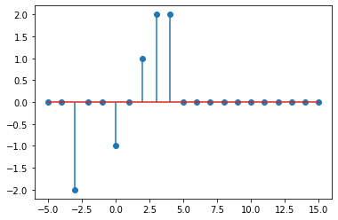

```python
pylab.stem(n,x1,use_line_collection=True)
```

# Ejercicio b) Generar y graficar la secuencia mostrada:

```python
xb = np.array([0,1,2,3,2,1,0])
nb= np.array([-1,0,1,2,3,4,5])
x2b=(-2*xb)
ne1,e1=dsp.sigshift(xb,nb,1)
ne2,e2=dsp.sigshift(xb,nb,0)
ne3,e3=dsp.sigshift(xb,nb,-1)
```

En esta sección realizamos los desplazamientos en las señales

```python
nsum1,sum1=dsp.senal_sum(e1,ne1,e2,ne2)
nf,sumf=dsp.senal_sum(sum1,nsum1,e3,ne3)
```

En esta sección realizamos las sumas de las señales desfasadas

```
<StemContainer object of 3 artists>
```

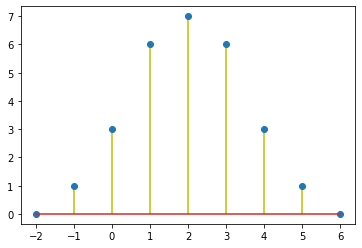

```python
plt.stem(nf,sumf,'y')
```

Gráfica de la señal

# Ejercicio c) Generar una suma de sinusoides

```python
nc=np.arange(-100,101,4)
x1c=np.sin(0.2*np.pi*nc)
x2c=np.sin(0.3*np.pi*nc)
xc=x1c+x2c
```

En esta parte del código generamos as señales sinousoidales y las sumamos

```
<StemContainer object of 3 artists>
```

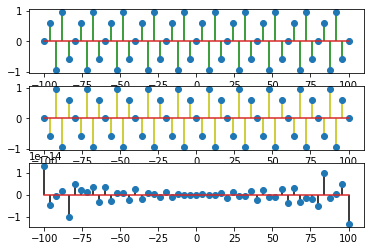

```python
plt.subplot(3,1,1)
plt.stem(nc,x1c,'g',use_line_collection=True)
plt.subplot(3,1,2)
plt.stem(nc,x2c,'y')
plt.subplot(3,1,3)
plt.stem(nc,xc,'k')
```

Usamos un subplot para graficar las señales de manera más ordenada y que sean más fáciles de entender.

```
<StemContainer object of 3 artists>
```

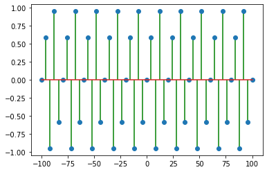

```python
plt.stem(nc,x1c,'g',use_line_collection=True)
```

```
<StemContainer object of 3 artists>
```

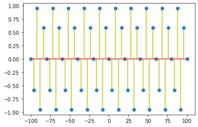

```python
plt.stem(nc,x2c,'y')
```

```
<StemContainer object of 3 artists>
```

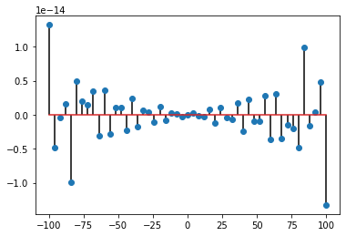

```python
plt.stem(nc,xc,'k')
```

También se graficó a las sinusoides por separado para entender mejor el comportamiento individual de cada una.

# Ejercicio d) Mutiplicación de una señal exponencial con la señal escalón

```python
nd=np.arange(-40,61,1)
exp=dsp.exp_cpl(nd,-0.1)
sinu=np.sin(0.25*np.pi*nd)
x1d=exp*sinu
```

En esta sección definimos las señales exponenciales y sinusoidales para luego multiplicarlas entre ellas.

```
<StemContainer object of 3 artists>
```

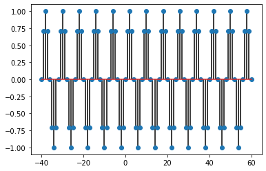

```python
plt.stem(nd,sinu,'k')
```

Gráfica de la señal sinusoidal

```
<StemContainer object of 3 artists>
```

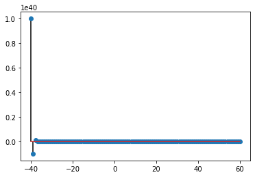

```python
plt.stem(nd,exp,'k')
```

Gráfica de la señal exponencial

```
<StemContainer object of 3 artists>
```

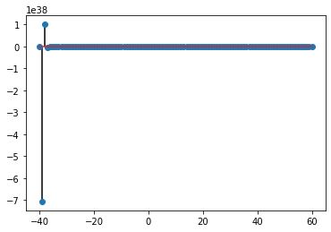

```python
plt.stem(nd,x1d,'k')
```

Gráfica de la señal resultante de la multipicación de ambas

```python
n1,e1=dsp.step(50, -40, 60)
n2,e2=dsp.step(10, -40, 60)
x2d=e1-e2
```

En esta sección definimos las señales escalón y luego las restamos entre ellas.

```
<StemContainer object of 3 artists>
```

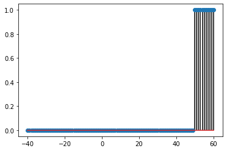

```python
plt.stem(n1,e1,'k')
```

Escalón situado en 50

```
<StemContainer object of 3 artists>
```

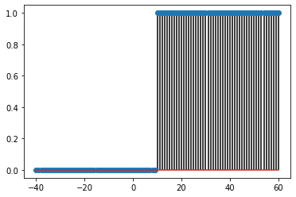

```python
plt.stem(n2,e2,'k')
```

Escalón situado en 10

```
<StemContainer object of 3 artists>
```

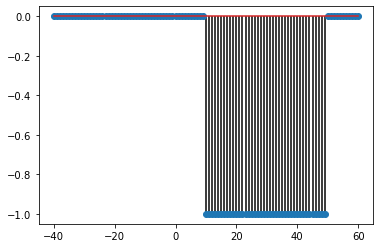

```python
plt.stem(n1,x2d,'k')
```

Resta entre ambas señales escalón.

```
<StemContainer object of 3 artists>
```

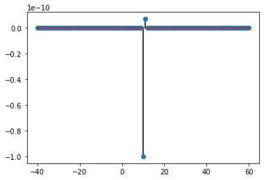

```python
yd=x1d*x2d
plt.stem(n1,yd,'k')
```

Multiplicación entre las señales exponencial y escalón.

# Ejercicio #2: Procesar señales en sistemas discretos usando la convolución

```python
import scipy.signal as sp
ncx = np.arange(-3,4,1)
nch = np.arange(-1,4,1)
xc=np.array([-2,-1,0,1,0,-1,-2])
hc=np.array([1,1,1,1,1])
conv=sp.convolve(xc,hc)
```

En esta sección del código inportamos a la librería spicy signal para poder eralizar la convolución entre las señales, también definimos las señales y sus rangos.

```
<StemContainer object of 3 artists>
```

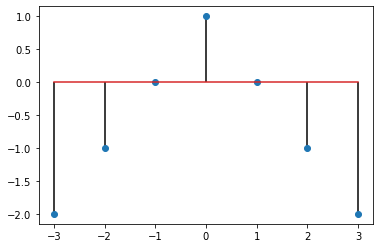

```python
plt.stem(ncx,xc,'k')
```

Gráfica de la señal x[n]

```
<StemContainer object of 3 artists>
```

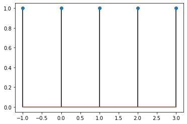

```python
plt.stem(nch,hc,'k')
```

Gráfica de la señal h[n]

```
<StemContainer object of 3 artists>
```

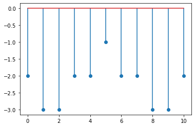

```python
stem(conv)
```

Gráfica de resultado de la convolución.